# DADA2 pipeline on A2 data

Michael McLaren

2020-11-06

This document analyzes the amplicon data from the A2 sequencing center using a modified version of the DADA2 Pipeline version 1.16 (https://benjjneb.github.io/dada2/tutorial.html).

## Setup

Load the libraries

```r
library(here)
library(tidyverse)
library(fs)
library(dada2); packageVersion("dada2")
```

```
## [1] '1.18.0'
```

```r
import::from(Biostrings, complement, reverseComplement, width, DNAString,
  readDNAStringSet)
import::from(DECIPHER, TrimDNA)
```

Path for saving dada2 results:

```r
results_path <- here("output", "a2", "dada2")
dir.create(results_path, recursive = TRUE)
```

Path to the fastq files:

```r
reads_path <- here("data", "a2", "reads")
dir_ls(path(reads_path, "raw")) %>% path_file %>% head
```

```
## [1] "1-1_S27_L001_R1_001.fastq.gz" "1-1_S27_L001_R2_001.fastq.gz"
## [3] "1-2_S70_L001_R1_001.fastq.gz" "1-2_S70_L001_R2_001.fastq.gz"
## [5] "1-3_S88_L001_R1_001.fastq.gz" "1-3_S88_L001_R2_001.fastq.gz"
```

Let’s get a data frame with the sample names, paths to the raw reads, and paths to the (to-be-created) filtered reads.

```r
ftb <- tibble(path = dir_ls(path(reads_path, "raw"), glob = "*.fastq.gz")) %>%
  mutate(
    read_direction = case_when(
      str_detect(path, "_R1_") ~ "R1",
      str_detect(path, "_R2_") ~ "R2"
    ),
    fastq_sample_id = str_extract(path %>% path_file, "[^_]+"),
    dna_sample_id = str_replace(fastq_sample_id, "-", "_") %>% str_to_lower,
    sample_id = str_c("A2_", dna_sample_id),
    path_filt = path(reads_path, "filtered",
      str_glue("{fastq_sample_id}_{read_direction}_filt.fastq.gz")
    )
  ) %>%
  pivot_wider(names_from = read_direction, values_from = c(path, path_filt))
# Check
ftb %>% head %>% mutate(across(starts_with("path"), path_file)) %>% glimpse
```

```
## Rows: 6
## Columns: 7
## $ fastq_sample_id <chr> "1-1", "1-2", "1-3", "1-4", "10-1", "10-2"
## $ dna_sample_id   <chr> "1_1", "1_2", "1_3", "1_4", "10_1", "10_2"
## $ sample_id       <chr> "A2_1_1", "A2_1_2", "A2_1_3", "A2_1_4", "A2_10_…
## $ path_R1         <chr> "1-1_S27_L001_R1_001.fastq.gz", "1-2_S70_L001_R…
## $ path_R2         <chr> "1-1_S27_L001_R2_001.fastq.gz", "1-2_S70_L001_R…
## $ path_filt_R1    <chr> "1-1_R1_filt.fastq.gz", "1-2_R1_filt.fastq.gz",…
## $ path_filt_R2    <chr> "1-1_R2_filt.fastq.gz", "1-2_R2_filt.fastq.gz",…
```

## Check sequences

Are primer sequences present? What is the length of the amplified region vs the sequence?

The [Illumina manual](https://support.illumina.com/documents/documentation/chemistry_documentation/16s/16s-metagenomic-library-prep-guide-15044223-b.pdf) lists the primer sequences as

> 16S Amplicon PCR Forward Primer = 5’ TCGTCGGCAGCGTCAGATGTGTATAAGAGACAGCCTACGGGNGGCWGCAG 16S Amplicon PCR Reverse Primer = 5’ GTCTCGTGGGCTCGGAGATGTGTATAAGAGACAGGACTACHVGGGTATCTAATCC

and states that the sequenced region is V3-V4 and approximately 460 bp long.

Let’s look to see if the primer sequences are present.

```r
reads <- ftb %>%
  filter(dna_sample_id == "5_1") %>%
  select(R1 = path_R1, R2 = path_R2) %>%
  c %>%
  map(readDNAStringSet, format = "fastq")
reads
```

```
## $R1
## DNAStringSet object of length 72:
##      width seq                                        names
##  [1]   301 CCTACGGGAGGCTGCAGTGG...TCGGACTAGAGGGTAGTGG M02019:284:000000...
##  [2]   301 CCTACGGGTGGCAGCAGTGA...CATTTGCAGTTGATACTGT M02019:284:000000...
##  [3]   301 CCTACGGGGGGCAGCAGTGA...AAATTGCAGTTGATACTGG M02019:284:000000...
##  [4]   301 CCTACGGGGGGCAGCAGTAG...CCATTGAGGTTCATTGGAA M02019:284:000000...
##  [5]   301 CCTACGGGTGGCAGCAGTGG...CCTGGGAACTGCATCTGAG M02019:284:000000...
##  ...   ... ...
## [68]   301 CCTACGGGTGGCTGCAGTGG...ACATTGTGGGTGCGACTGG M02019:284:000000...
## [69]   301 CCTACGGGTGGCAGCAGTGG...AAACTGGAGTGGCGGCGGG M02019:284:000000...
## [70]   301 CCTACGGGAGGCTGCAGTGG...CAGTTGAAGGTCATTGGAG M02019:284:000000...
## [71]   301 CCTACGGGAGGCTGCAGTGA...ACATTGCAGTTGAAACTGG M02019:284:000000...
## [72]   301 CCTACGGGAGGCAGCAGTGA...AAATTGCAGTTGATACTGG M02019:284:000000...
##
## $R2
## DNAStringSet object of length 72:
##      width seq                                        names
##  [1]   301 GACTACACGGGTATCTAATC...TGCTGGCACGGATTTAGCC M02019:284:000000...
##  [2]   301 GACTACACGGGTATCTAATC...TTCTGGCACCGAGTTAGCC M02019:284:000000...
##  [3]   301 GACTACCGGGGTATCTAATC...TGCTGGCACCGAGTTAGCC M02019:284:000000...
##  [4]   301 GACTACCCGGGTATCTAATC...TGCTGGCCCCTAGTTAGCC M02019:284:000000...
##  [5]   301 GACTACAGGGGTATCTAATC...TGCTGGCACGGAGTTAGCC M02019:284:000000...
##  ...   ... ...
## [68]   301 GANTACACGGGTATCTAATC...TGCTGGCCCGGCGTTAGAC M02019:284:000000...
## [69]   301 GACTACCAGGGTATCTAATC...AGCTGGGACGGAGGTAGCC M02019:284:000000...
## [70]   301 GACTACTCGGGTATCTAATC...TGCTGGCACGGAGTTAGCC M02019:284:000000...
## [71]   301 GACTACAAGGGTATCTAATC...TGCTGGCACGGAGTTCGCC M02019:284:000000...
## [72]   301 GACTACAAGGGTATCTAATC...TGCTGGCCCGGCGTTAGCC M02019:284:000000...
```

Only part of the described primer sequences are actually present:

```r
primers <- c(R1 = "CCTACGGGNGGCWGCAG", R2 = "GACTACHVGGGTATCTAATCC")
trim_left <- primers %>% map_int(nchar)
```

### Check length of amplicon region

Load the 16S sequences that were extracted from the reference whole genomes,

```r
dna <- Biostrings::readDNAStringSet(
  here("output", "strain-data", "reference-16s-genes.fasta")
)
```

and extraction with `DECIPHER::TrimDNA()`

```r
primers.dna <- primers %>% map(DNAString)
x <- TrimDNA(dna, primers.dna[[1]], primers.dna[[2]] %>% reverseComplement,
  type = "sequences")
```

```
## Finding left pattern: 82.1% internal, 0% flanking
##
## Finding right pattern: 81% internal, 0% flanking
##
## Time difference of 0.07 secs
```

```r
width(x) %>% summary
```

```
##    Min. 1st Qu.  Median    Mean 3rd Qu.    Max.
##    60.0   402.0   422.0   369.6   427.0   428.0
```

Note, primer sequences are trimmed from the output sequences. The true length of the amplicon is 420-430 bp *excluding* the primer sequences, leaving us with about 130 bp of overlap to work with.

## Pick truncation and max-EE params with FIGARO

I’ll set the target length to 430 and bump up the requested overlap to 30 to buffer for any taxa with longer-than-expected sequences.

```r
target_len <- 430 # Set to length _excluding_ primer seqs
cmd <- "docker"
args <- c(
  "container run",
  "--rm",
  "-e AMPLICONLENGTH={target_len}",
  "-e FORWARDPRIMERLENGTH={trim_left[1]}",
  "-e REVERSEPRIMERLENGTH={trim_left[2]}",
  "-e MINIMUMOVERLAP=30",
  "-v {file.path(reads_path, 'raw')}:/data/input",
  "-v {file.path(results_path, 'figaro')}:/data/output",
  "figaro"
) %>%
  map_chr(str_glue)
system2(cmd, args)
```

```r
x <- file.path(results_path, "figaro", "trimParameters.json") %>%
  jsonlite::fromJSON()
head(x)
```

```
##   trimPosition maxExpectedError readRetentionPercent    score
## 1     276, 222             4, 3                80.70 67.70196
## 2     277, 221             4, 3                80.68 67.68008
## 3     271, 227             4, 3                80.66 67.66257
## 4     272, 226             4, 3                80.66 67.65820
## 5     273, 225             4, 3                80.65 67.64507
## 6     275, 223             4, 3                80.63 67.62902
```

```r
trunc_len <- x[[1, "trimPosition"]]
max_ee <- x[[1, "maxExpectedError"]]
```

Overlap:

```r
sum(trunc_len) - sum(trim_left) - target_len
```

```
## [1] 30
```

## Inspect read quality profiles w/ trim + trunc parameters

```r
set.seed(42)
idx <- sample(nrow(ftb), 9)
idx
```

```
## [1] 49 65 25 74 18 96 47 24 71
```

```r
ftb %>% slice(idx) %>% pull(sample_id)
```

```
## [1] "A2_21_1" "A2_26_1" "A2_16_1" "A2_4_2"  "A2_14_2" "A2_9_4"  "A2_20_3"
## [8] "A2_15_4" "A2_3_3"
```

```r
qps <- ftb %>%
  slice(idx) %>%
  select(R1 = path_R1, R2 = path_R2) %>%
  c %>%
  map(plotQualityProfile)
```

```r
p1 <- qps[["R1"]] +
    geom_hline(yintercept = 30, color = "grey") +
    geom_vline(xintercept = c(trim_left[1], trunc_len[1]), color = "darkred")
p2 <- qps[["R2"]] +
    geom_hline(yintercept = 30, color = "grey") +
    geom_vline(xintercept = c(trim_left[2], trunc_len[2]), color = "darkred")
```

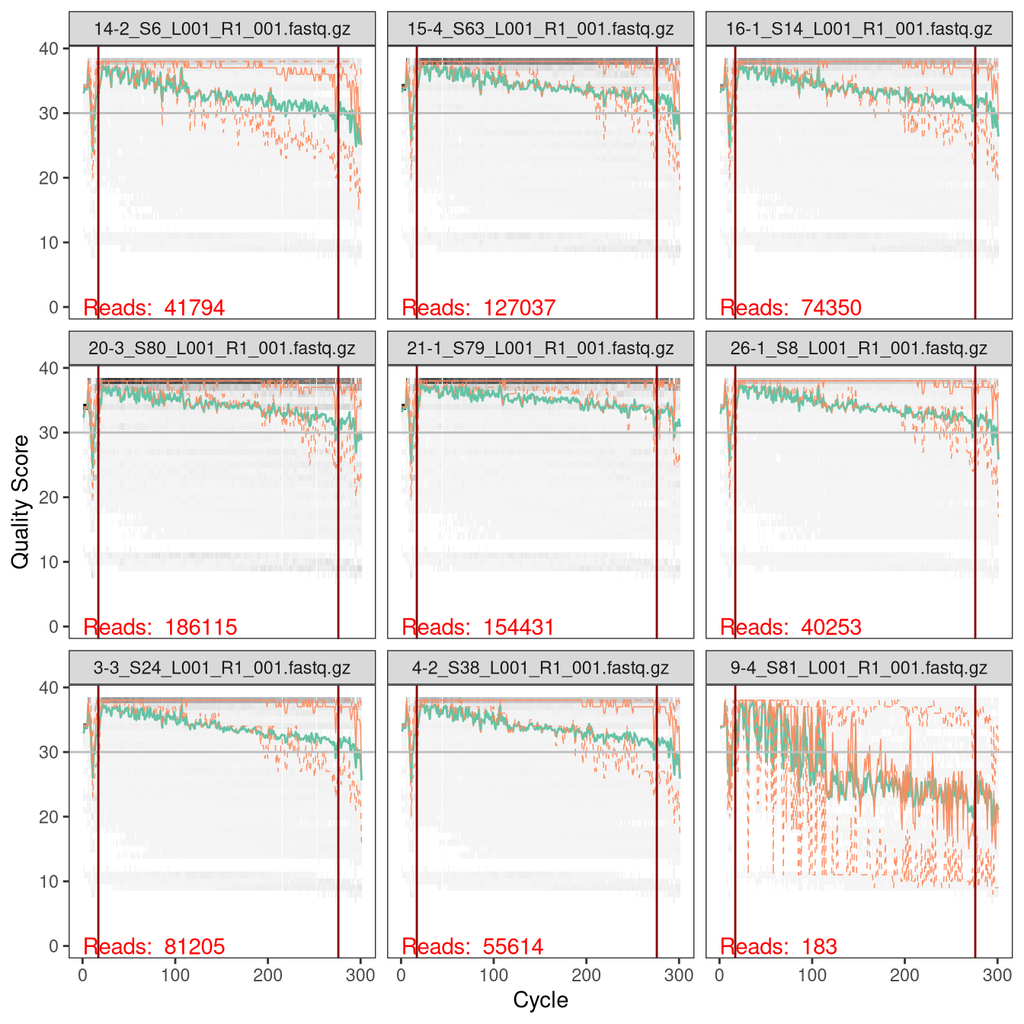

```r
p1
```

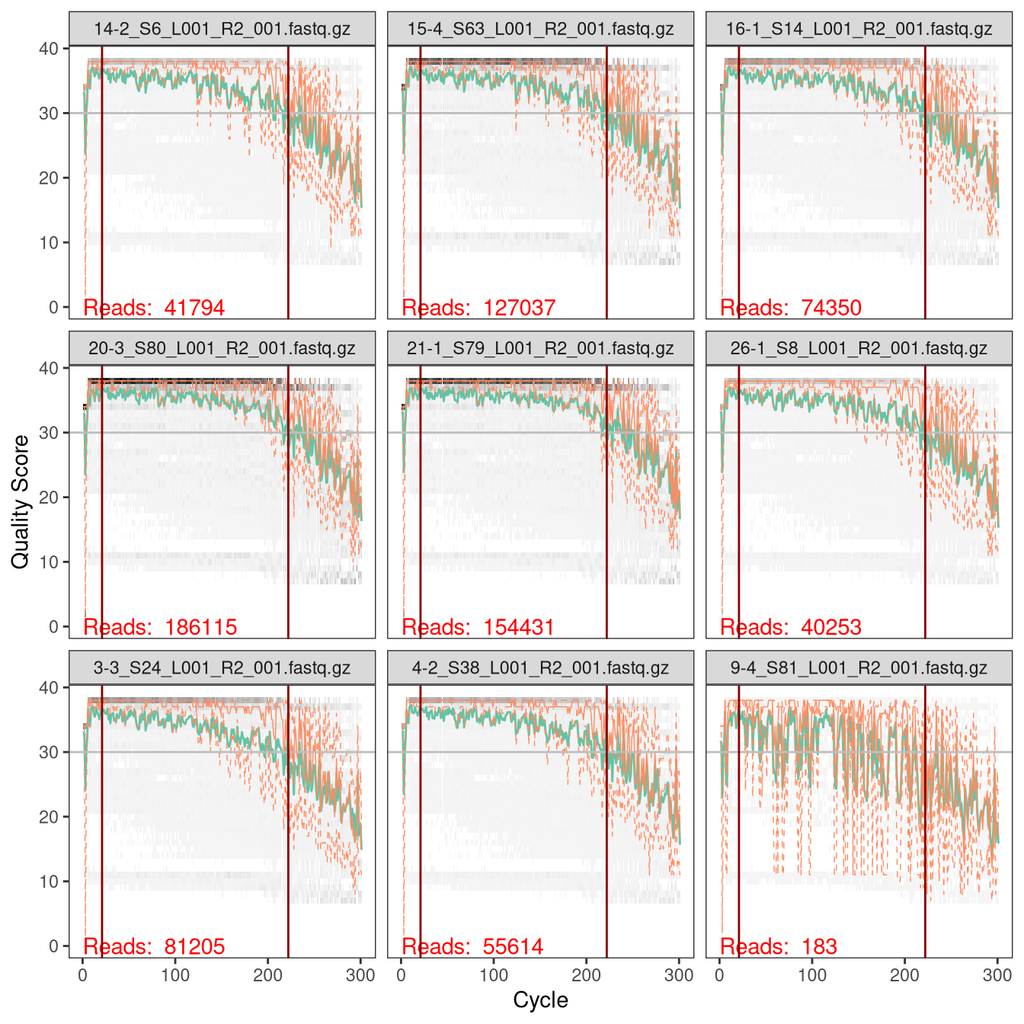

```r
p2
```

```r
ggsave(plot = p1, file.path(results_path, "quality-profiles-r1.pdf"),
    width = 10, height = 10, units = "in")
ggsave(plot = p2, file.path(results_path, "quality-profiles-r2.pdf"),
    width = 10, height = 10, units = "in")
```

The truncation parameters chosen by Figaro look good.

## Filter and trim

Set up a lists with the paths to the forward and reverse reads (raw and filtered). Note, the file paths are named by sample id so that later DADA2 functions will name the samples by sample id instead of file name.

```r
path_raw <- list(R1 = ftb$path_R1, R2 = ftb$path_R2) %>%
  map(set_names, ftb$sample_id)
path_filt <- list(R1 = ftb$path_filt_R1, R2 = ftb$path_filt_R2) %>%
  map(set_names, ftb$sample_id)
# Check
path_filt %>% map(tail, 4) %>% map(names)
```

```
## $R1
## [1] "A2_9_1" "A2_9_2" "A2_9_3" "A2_9_4"
##
## $R2
## [1] "A2_9_1" "A2_9_2" "A2_9_3" "A2_9_4"
```

```r
path_filt %>% map(tail, 4) %>% map(path_file)
```

```
## $R1
## [1] "9-1_R1_filt.fastq.gz" "9-2_R1_filt.fastq.gz" "9-3_R1_filt.fastq.gz"
## [4] "9-4_R1_filt.fastq.gz"
##
## $R2
## [1] "9-1_R2_filt.fastq.gz" "9-2_R2_filt.fastq.gz" "9-3_R2_filt.fastq.gz"
## [4] "9-4_R2_filt.fastq.gz"
```

Then filter and trim.

```r
out <- filterAndTrim(
  path_raw[[1]], path_filt[[1]],
  path_raw[[2]], path_filt[[2]],
  trimLeft = trim_left, truncLen = trunc_len,
  maxN = 0, maxEE = max_ee, truncQ = 2, rm.phix = TRUE,
  compress = TRUE, multithread = TRUE)
```

```
## Creating output directory: /home/michael/research/vivo-vitro/main/data/a2/reads/filtered
```

```r
head(out)
```

```
##                               reads.in reads.out
## 1-1_S27_L001_R1_001.fastq.gz     45111     23694
## 1-2_S70_L001_R1_001.fastq.gz    225636    159307
## 1-3_S88_L001_R1_001.fastq.gz    236498    146999
## 1-4_S96_L001_R1_001.fastq.gz    404248    308241
## 10-1_S26_L001_R1_001.fastq.gz      367       151
## 10-2_S10_L001_R1_001.fastq.gz      367       121
```

```r
# Save in case of crash downstream
saveRDS(out, file.path(results_path, "filt-out.Rds"))
```

## Learn the error rates

```r
errs <- path_filt %>%
  map(learnErrors, multithread = TRUE)
```

```
## 165304419 total bases in 638241 reads from 4 samples will be used for learning the error rates.
## 128286441 total bases in 638241 reads from 4 samples will be used for learning the error rates.
```

```r
saveRDS(errs, file.path(results_path, "error-models.Rds"))
```

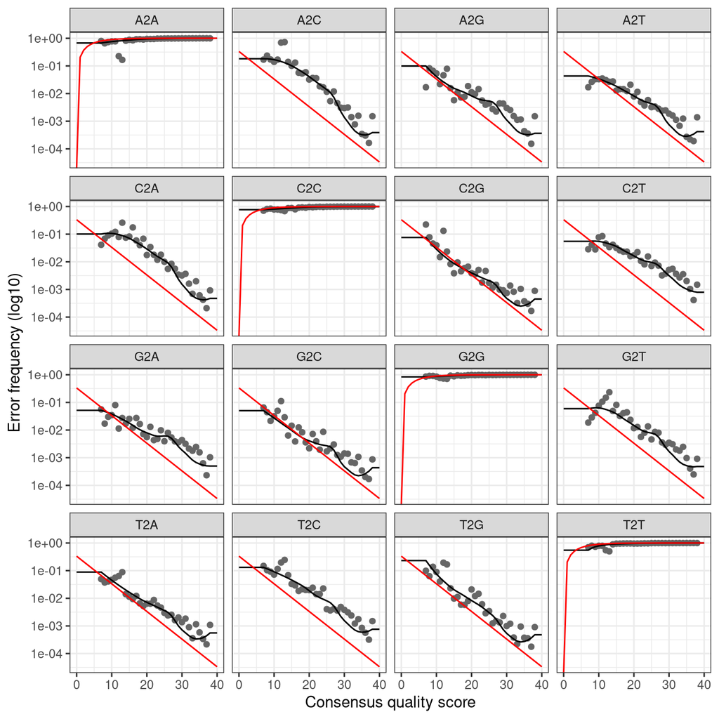

```r
plotErrors(errs[[1]], nominalQ = TRUE)
```

```r
ggsave(file.path(results_path, "error-profile-r1.pdf"),
    width = 9, height = 9, units = "in")
```

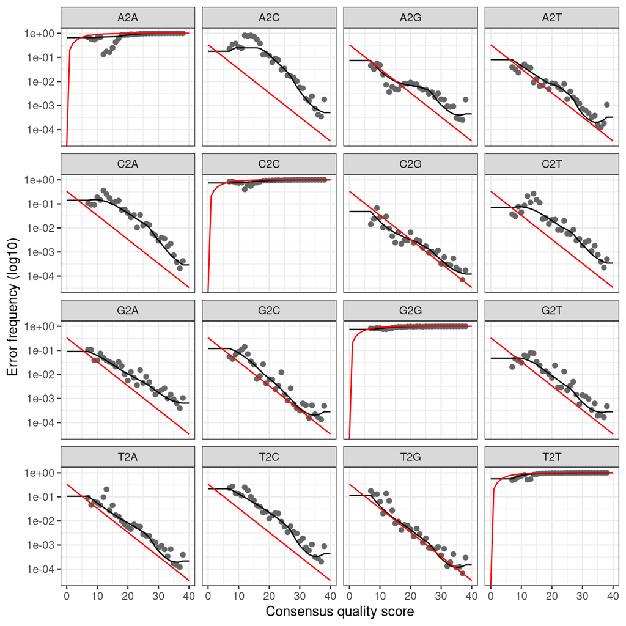

```r
plotErrors(errs[[2]], nominalQ = TRUE)
```

```r
ggsave(file.path(results_path, "error-profile-r2.pdf"),
    width = 9, height = 9, units = "in")
```

## Sample inference

The following settings for the `dada()` inference step are used:

- Pseudo-pooling used to increase sensitivity
  - `pool = "pseudo"` option
  - `PSEUDO_PREVALENCE = 4` (increased from default of 2 to reduce the number of spurious low-prev ASVs seen in the pilot)
- The inference step (`dada()`) is run two different ways: The default settings, and with `OMEGA_C = 2` (which prevents error correction, so that we can assign abundances using just the error-free read-pairs).

### Default `OMEGA_C`

Sample inference w/ `dada()`

```r
dadas <- map2(
  path_filt,
  errs,
  dada,
  multithread = TRUE, pool = "pseudo",
  PSEUDO_PREVALENCE = 4
)
```

```
## Sample 1 - 23694 reads in 6914 unique sequences.
## Sample 2 - 159307 reads in 36951 unique sequences.
## Sample 3 - 146999 reads in 32439 unique sequences.
## Sample 4 - 308241 reads in 63270 unique sequences.
## Sample 5 - 151 reads in 121 unique sequences.
## Sample 6 - 121 reads in 101 unique sequences.
## Sample 7 - 222185 reads in 43933 unique sequences.
## Sample 8 - 65178 reads in 15427 unique sequences.
## Sample 9 - 265636 reads in 51064 unique sequences.
## Sample 10 - 52015 reads in 12769 unique sequences.
## Sample 11 - 215087 reads in 44517 unique sequences.
## Sample 12 - 224 reads in 173 unique sequences.
## Sample 13 - 96055 reads in 21304 unique sequences.
## Sample 14 - 73 reads in 58 unique sequences.
## Sample 15 - 123223 reads in 18231 unique sequences.
## Sample 16 - 56987 reads in 10607 unique sequences.
## Sample 17 - 57732 reads in 13031 unique sequences.
## Sample 18 - 30803 reads in 11114 unique sequences.
## Sample 19 - 406606 reads in 73850 unique sequences.
## Sample 20 - 158475 reads in 36926 unique sequences.
## Sample 21 - 30 reads in 25 unique sequences.
## Sample 22 - 49466 reads in 12686 unique sequences.
## Sample 23 - 119225 reads in 26670 unique sequences.
## Sample 24 - 101703 reads in 22233 unique sequences.
## Sample 25 - 57293 reads in 15010 unique sequences.
## Sample 26 - 362456 reads in 74776 unique sequences.
## Sample 27 - 38979 reads in 10237 unique sequences.
## Sample 28 - 57039 reads in 14971 unique sequences.
## Sample 29 - 169149 reads in 38091 unique sequences.
## Sample 30 - 125 reads in 103 unique sequences.
## Sample 31 - 14 reads in 13 unique sequences.
## Sample 32 - 164750 reads in 36492 unique sequences.
## Sample 33 - 460682 reads in 84552 unique sequences.
## Sample 34 - 47090 reads in 12372 unique sequences.
## Sample 35 - 106985 reads in 22507 unique sequences.
## Sample 36 - 154463 reads in 34886 unique sequences.
## Sample 37 - 258608 reads in 47076 unique sequences.
## Sample 38 - 74174 reads in 18181 unique sequences.
## Sample 39 - 126941 reads in 18555 unique sequences.
## Sample 40 - 64512 reads in 15480 unique sequences.
```

[output cut: 140 more lines]

```
## Sample 84 - 91177 reads in 20566 unique sequences.
## Sample 85 - 606632 reads in 100300 unique sequences.
## Sample 86 - 14 reads in 13 unique sequences.
## Sample 87 - 115 reads in 92 unique sequences.
## Sample 88 - 62166 reads in 16734 unique sequences.
## Sample 89 - 61312 reads in 16169 unique sequences.
## Sample 90 - 38730 reads in 9659 unique sequences.
## Sample 91 - 67164 reads in 15776 unique sequences.
## Sample 92 - 134537 reads in 29928 unique sequences.
## Sample 93 - 369584 reads in 64599 unique sequences.
## Sample 94 - 51973 reads in 14251 unique sequences.
## Sample 95 - 110235 reads in 23004 unique sequences.
## Sample 96 - 54 reads in 47 unique sequences.
##
##    selfConsist step 2
```

```r
saveRDS(dadas, file.path(results_path, "dadas-1.Rds"))
```

Check the results:

```r
dadas[[1]][[1]]
```

```
## dada-class: object describing DADA2 denoising results
## 107 sequence variants were inferred from 6914 input unique sequences.
## Key parameters: OMEGA_A = 1e-40, OMEGA_C = 1e-40, BAND_SIZE = 16
```

```r
head(getSequences(dadas[[1]][[1]]), 2)
```

```
## [1] "TGGGGAATATTGGACAATGGGCGCAAGCCTGATCCAGCAATGCCGCGTGTGTGAAGAAGG…"
## [2] "GCGCGAAACCTCCGCAATGCACGCAAGTGCGACGGGGGAACCCCAAGTGCCACTCTTAAC…"
```

Merge paired reads,

```r
mergers <- mergePairs(
  dadas[[1]], path_filt[[1]],
  dadas[[2]], path_filt[[2]],
  verbose = TRUE)
saveRDS(mergers, file.path(results_path, "mergers-1.Rds"))
```

Construct sequence table

```r
seqtab <- makeSequenceTable(mergers)
saveRDS(seqtab, file.path(results_path, "seqtab-1.Rds"))
dim(seqtab)
```

```
## [1]    96 24716
```

Inspect distribution of sequence lengths

```r
table(nchar(getSequences(seqtab)))
```

```
##
##   259   260   262   267   271   272   280   281   311   314   318   323
##    59    23     2     9     1     1     3     1     1     5     1     1
##   325   326   328   335   339   341   342   343   350   358   361   362
##     2     1     1     3     1     2     3     3     3     1     1     1
##   366   367   369   370   372   374   380   382   384   385   386   387
##     1     1     1     3     1     1     1     2    15    12    30    12
##   388   390   392   393   398   399   400   401   402   403   404   405
##     2     1     3     2     1     2     2     9  3921   804  1968    98
##   406   407   408   409   410   411   412   414   416   417   418   419
##    16   113   958     3     3     3     3     2     1     1     2     1
##   420   421   422   423   424   425   426   427   428   429   430   431
##     3    84 10042     6     6    18    15  5152  1227    13     3     2
##   433   434   437   439   440   441   442   444   445   447
##     4     1     1     3     1     1     1     1     2     2
```

Remove chimeras (with ‘pooled’ method)

```r
seqtab.nochim <- removeBimeraDenovo(seqtab, method = "pooled",
    multithread = TRUE, verbose = TRUE)
```

```
## Identified 23937 bimeras out of 24716 input sequences.
```

```r
saveRDS(seqtab.nochim, file.path(results_path, "seqtab-nochim-1.Rds"))
dim(seqtab.nochim)
```

```
## [1]  96 779
```

```r
sum(seqtab.nochim) / sum(seqtab)
```

```
## [1] 0.8122602
```

Track reads through the pipeline,

```r
getN <- function(x) sum(getUniques(x))
track <- cbind(out, sapply(dadas[[1]], getN), sapply(dadas[[2]], getN),
    sapply(mergers, getN), rowSums(seqtab.nochim))
colnames(track) <- c("input", "filtered", "denoised_r1", "denoised_r2", "merged",
    "nochim")
rownames(track) <- ftb$sample_id
track <- as_tibble(track, rownames = "sample_id")
write_csv(track, file.path(results_path, "track-1.csv"))
head(track)
```

```
## # A tibble: 6 x 7
##   sample_id  input filtered denoised_r1 denoised_r2 merged nochim
##   <chr>      <dbl>    <dbl>       <dbl>       <dbl>  <dbl>  <dbl>
## 1 A2_1_1     45111    23694       23076       23247  22639  22556
## 2 A2_1_2    225636   159307      157884      158604 154855 137754
## 3 A2_1_3    236498   146999      145037      146160 142083 133077
## 4 A2_1_4    404248   308241      306780      307463 301257 255746
## 5 A2_10_1      367      151         143         137    111    101
## 6 A2_10_2      367      121         112         119     98     82
```

### `OMEGA_C = 2`

```r
rm(dadas, mergers, seqtab, seqtab.nochim, track)
```

Sample inference w/ `dada()`

```r
dadas <- map2(
  path_filt,
  errs,
  dada,
  multithread = TRUE, pool = "pseudo",
  PSEUDO_PREVALENCE = 4,
  OMEGA_C = 2
)
```

```
## Sample 1 - 23694 reads in 6914 unique sequences.
## Sample 2 - 159307 reads in 36951 unique sequences.
## Sample 3 - 146999 reads in 32439 unique sequences.
## Sample 4 - 308241 reads in 63270 unique sequences.
## Sample 5 - 151 reads in 121 unique sequences.
## Sample 6 - 121 reads in 101 unique sequences.
## Sample 7 - 222185 reads in 43933 unique sequences.
## Sample 8 - 65178 reads in 15427 unique sequences.
## Sample 9 - 265636 reads in 51064 unique sequences.
## Sample 10 - 52015 reads in 12769 unique sequences.
## Sample 11 - 215087 reads in 44517 unique sequences.
## Sample 12 - 224 reads in 173 unique sequences.
## Sample 13 - 96055 reads in 21304 unique sequences.
## Sample 14 - 73 reads in 58 unique sequences.
## Sample 15 - 123223 reads in 18231 unique sequences.
## Sample 16 - 56987 reads in 10607 unique sequences.
## Sample 17 - 57732 reads in 13031 unique sequences.
## Sample 18 - 30803 reads in 11114 unique sequences.
## Sample 19 - 406606 reads in 73850 unique sequences.
## Sample 20 - 158475 reads in 36926 unique sequences.
## Sample 21 - 30 reads in 25 unique sequences.
## Sample 22 - 49466 reads in 12686 unique sequences.
## Sample 23 - 119225 reads in 26670 unique sequences.
## Sample 24 - 101703 reads in 22233 unique sequences.
## Sample 25 - 57293 reads in 15010 unique sequences.
## Sample 26 - 362456 reads in 74776 unique sequences.
## Sample 27 - 38979 reads in 10237 unique sequences.
## Sample 28 - 57039 reads in 14971 unique sequences.
## Sample 29 - 169149 reads in 38091 unique sequences.
## Sample 30 - 125 reads in 103 unique sequences.
## Sample 31 - 14 reads in 13 unique sequences.
## Sample 32 - 164750 reads in 36492 unique sequences.
## Sample 33 - 460682 reads in 84552 unique sequences.
## Sample 34 - 47090 reads in 12372 unique sequences.
## Sample 35 - 106985 reads in 22507 unique sequences.
## Sample 36 - 154463 reads in 34886 unique sequences.
## Sample 37 - 258608 reads in 47076 unique sequences.
## Sample 38 - 74174 reads in 18181 unique sequences.
## Sample 39 - 126941 reads in 18555 unique sequences.
## Sample 40 - 64512 reads in 15480 unique sequences.
```

[output cut: 140 more lines]

```
## Sample 84 - 91177 reads in 20566 unique sequences.
## Sample 85 - 606632 reads in 100300 unique sequences.
## Sample 86 - 14 reads in 13 unique sequences.
## Sample 87 - 115 reads in 92 unique sequences.
## Sample 88 - 62166 reads in 16734 unique sequences.
## Sample 89 - 61312 reads in 16169 unique sequences.
## Sample 90 - 38730 reads in 9659 unique sequences.
## Sample 91 - 67164 reads in 15776 unique sequences.
## Sample 92 - 134537 reads in 29928 unique sequences.
## Sample 93 - 369584 reads in 64599 unique sequences.
## Sample 94 - 51973 reads in 14251 unique sequences.
## Sample 95 - 110235 reads in 23004 unique sequences.
## Sample 96 - 54 reads in 47 unique sequences.
##
##    selfConsist step 2
```

```r
saveRDS(dadas, file.path(results_path, "dadas-2.Rds"))
```

Check the results:

```r
dadas[[1]][[1]]
```

```
## dada-class: object describing DADA2 denoising results
## 151 sequence variants were inferred from 6914 input unique sequences.
## Key parameters: OMEGA_A = 1e-40, OMEGA_C = 2, BAND_SIZE = 16
```

```r
head(getSequences(dadas[[1]][[1]]), 2)
```

```
## [1] "TGGGGAATATTGGACAATGGGCGCAAGCCTGATCCAGCAATGCCGCGTGTGTGAAGAAGG…"
## [2] "GCGCGAAACCTCCGCAATGCACGCAAGTGCGACGGGGGAACCCCAAGTGCCACTCTTAAC…"
```

Merge paired reads,

```r
mergers <- mergePairs(
  dadas[[1]], path_filt[[1]],
  dadas[[2]], path_filt[[2]],
  verbose = TRUE)
saveRDS(mergers, file.path(results_path, "mergers-2.Rds"))
```

Construct sequence table

```r
seqtab <- makeSequenceTable(mergers)
saveRDS(seqtab, file.path(results_path, "seqtab-2.Rds"))
dim(seqtab)
```

```
## [1]    96 27028
```

Inspect distribution of sequence lengths

```r
table(nchar(getSequences(seqtab)))
```

```
##
##   259   260   262   267   271   272   280   281   311   314   318   323
##    62    26     2     9     1     1     4     1     1     5     1     1
##   325   326   328   335   341   342   343   350   358   362   367   369
##     3     1     1     4     1     2     2     2     1     1     1     2
##   370   372   374   380   382   384   385   386   387   388   390   392
##     3     1     1     2     2    16    11    43    22     2     1     4
##   393   398   399   400   401   402   403   404   405   406   407   408
##     2     1     1     4    13  3445   591  1854    91    17    93  1039
##   409   410   411   412   414   417   418   420   421   422   423   424
##     3     2     2     2     3     1     1     1    49 12121     6     3
##   425   426   427   428   429   430   433   434   439   440   441   442
##    12    16  6264  1116    15     2     2     1     3     1     2     2
##   444   445   447
##     1     1     2
```

Remove chimeras (with ‘pooled’ method)

```r
seqtab.nochim <- removeBimeraDenovo(seqtab, method = "pooled",
    multithread = TRUE, verbose = TRUE)
```

```
## Identified 24723 bimeras out of 27028 input sequences.
```

```r
saveRDS(seqtab.nochim, file.path(results_path, "seqtab-nochim-2.Rds"))
dim(seqtab.nochim)
```

```
## [1]   96 2305
```

```r
sum(seqtab.nochim) / sum(seqtab)
```

```
## [1] 0.8138268
```

Track reads through the pipeline,

```r
getN <- function(x) sum(getUniques(x))
track <- cbind(out, sapply(dadas[[1]], getN), sapply(dadas[[2]], getN),
    sapply(mergers, getN), rowSums(seqtab.nochim))
colnames(track) <- c("input", "filtered", "denoised_r1", "denoised_r2", "merged",
    "nochim")
rownames(track) <- ftb$sample_id
track <- as_tibble(track, rownames = "sample_id")
write_csv(track, file.path(results_path, "track-2.csv"))
head(track)
```

```
## # A tibble: 6 x 7
##   sample_id  input filtered denoised_r1 denoised_r2 merged nochim
##   <chr>      <dbl>    <dbl>       <dbl>       <dbl>  <dbl>  <dbl>
## 1 A2_1_1     45111    23694       12832        7521   5391   5330
## 2 A2_1_2    225636   159307      100444       88247  67076  60246
## 3 A2_1_3    236498   146999       93930       77619  60554  56878
## 4 A2_1_4    404248   308241      201147      166876 130884 112831
## 5 A2_10_1      367      151          43          36     14     12
## 6 A2_10_2      367      121          34          42     20     17
```